# projeto_final

### Algoritmos não-supervisionados para clusterização [22E4_2]

## "Installs & Imports"...

```python
# %pip install scikit-learn-extra
# %pip install plotly
```

```python
import opendatasets as od
import pandas as pd
import matplotlib.pyplot as plt
import seaborn as sb
import scipy
import scipy.cluster.hierarchy as sch
import numpy as np
import plotly.express as px

# from tqdm.auto import tqdm
from sklearn.cluster import KMeans
from sklearn.datasets import make_blobs
from yellowbrick.cluster import KElbowVisualizer
from sklearn.decomposition import PCA
from sklearn.cluster import AgglomerativeClustering
from sklearn.preprocessing import StandardScaler
from sklearn.preprocessing import MinMaxScaler
from sklearn_extra.cluster import KMedoids
from sklearn.metrics import pairwise_distances_argmin_min

# tqdm.pandas(); # <-- Necessário?
```

## Configurações

```python
download_dataset = False
color_map="Blues"
clusters_number = 3
initializations_number = 10
maximum_iteration = 300
seed = 42
np.random.seed(seed)
```

## Funções

```python
# Exibe gráfico de correlação de colunas do dataframe original
def plot_columns_correlation(df):
    correlation_dataframe = df.corr()
    fig, ax = plt.subplots(figsize=(10, 8))
    sb.heatmap(correlation_dataframe, square=True, linewidths=.5, center=0,annot=True, cmap=color_map);

# Gera o gráfico de cotovelo para análise de número de clusters.
def plot_elbow_analysis(df):
    distortions = []

    K = range(1,10)

    for k in K:
        kmeanModel = KMeans(n_clusters= k, n_init=initializations_number, max_iter=maximum_iteration, random_state= seed)
        # kmeanModel = KMeans(n_clusters=k)
        kmeanModel.fit(df)
        distortions.append(kmeanModel.inertia_)

    plt.figure(figsize=(10, 5))
    plt.plot(K, distortions, 'bx-')
    plt.xlabel('k')
    plt.ylabel('Distorção')
    plt.title('Método do cotovelo mostrando o k ideal')
    plt.show()

# Exibe o gráfico de distância (euclidiana) entre as colunas do dataframe
def plot_distance_matrix_chart(df, show_annot):
    dist_matrix = scipy.spatial.distance_matrix(df, df, p=2)
    dist_matrix_df = pd.DataFrame(dist_matrix, index=df.index, columns=df.index)

    fig, ax = plt.subplots(figsize=(40, 20))
    sb.heatmap(dist_matrix_df, center=0, square=True, annot=show_annot, cmap=color_map).set(xlabel='', ylabel='');

# Clusteriza por kmeans.
# Retorna:
# O dataframe de dimensões reduzidas
# Os lables dos clusters de cada linha do dataframe
# Os centroides de cada um dos clusters
def get_pca_kmeans_cluster(df):
    pca = PCA(2)
    pca_df = pca.fit_transform(df)

    #  kmeans = KMeans(n_clusters=n_clusters, n_init=10, max_iter=300)
    # labels = kmeans.fit_predict(dataset)

    kmeans = KMeans(n_clusters= clusters_number, n_init=initializations_number, max_iter=maximum_iteration, random_state= seed)

    return pca_df, kmeans.fit_predict(pca_df), kmeans.cluster_centers_

# Clusteriza por kmeans.
# Retorna:
# O dataframe de dimensões reduzidas
# Os lables dos clusters de cada linha do dataframe
# Os centroides de cada um dos clusters
def get_kmeans_cluster(df):
    kmeans = KMeans(n_clusters= clusters_number, n_init=initializations_number, max_iter=maximum_iteration, random_state= seed)
    # kmeans = KMeans(n_clusters= clusters_number, random_state= seed)

    return df, kmeans.fit_predict(df), kmeans.cluster_centers_

# Gera dataframe contendo a coluna de clusterização por kmeans
def cluster(kmeans_cluster_labels, df):
    kmeans_label = kmeans_cluster_labels

    clustered_df = df.copy()
    clustered_df['kmeans_cluster'] = kmeans_label

    return clustered_df

# Gera o gráfico de clusters
def plot_pca_cluster(pca_df, kmeans_cluster_labels, centroids = None, show_centroids = False):
    unique_labels = np.unique(kmeans_cluster_labels)
    # labels = ['A', 'B', 'C']

    fig, ax = plt.subplots(figsize=(10, 5))

    for i in unique_labels:
        plt.scatter(pca_df[kmeans_cluster_labels == i , 0] , pca_df[kmeans_cluster_labels == i , 1], edgecolors='w', linewidths=1, label= 'Cluster {}'.format(i), s=100, alpha=0.8)
        # ax = plt.scatter(pca_df[label == i , 0] , pca_df[label == i , 1], edgecolors='w', linewidths=labels[1], label= i, s=100, alpha=0.8)

    if(show_centroids):
        plt.scatter(centroids[:,0] , centroids[:,1], s = 100, color = 'k', marker='x', linewidths=3)

    plt.legend()
    plt.show()

# Gera o gráfico de clusters
def plot_cluster(df, kmeans_cluster_labels, centroids = None, show_centroids = False, show_points_label = False):

    def plotlabel(xvar, yvar, label):
        ax.text(xvar+0.002, yvar, label)

    # unique_labels = np.unique(kmeans_cluster_labels)
    fig, ax = plt.subplots(figsize=(10, 5))

    pca = PCA(2)
    pca_data = pd.DataFrame(pca.fit_transform(df), columns=['PC1','PC2'])
    pca_data['cluster'] = pd.Categorical(kmeans_cluster_labels)
    pca_data['country'] = df.index

    # print(pca_data)
    fig = plt.figure(figsize=(30,10))
    # ax = sb.scatterplot(x = 'sepal_length', y = 'sepal_width', data=df)
    ax = sb.scatterplot(x="PC1", y="PC2", hue="cluster", data=pca_data, ax=ax, s=100, edgecolors='w', linewidths=1, alpha=0.8) #, label= 'Cluster {}'.format(i))
    # sb.scatterplot(x="PC1", y="PC2", hue="cluster", data=pca_data, ax=ax, s=100, edgecolors='w', linewidths=1, alpha=0.8) #, label= 'Cluster {}'.format(i))

    # Exibe o label do ponto
    if(show_points_label):
        pca_data.apply(lambda x: plotlabel(x['PC1'],  x['PC2'], x['country']), axis=1)

    if(show_centroids):
        plt.scatter(centroids[:,0] , centroids[:,1], s = 100, color = 'k', marker='x', linewidths=3)

    # plt.legend()

# Gera dendrograma
def plot_open_dendrogram(df):
    plt.figure(figsize=(20, 7));
    plt.grid(False);
    dendrogram = sch.dendrogram(sch.linkage(df, method='ward'), labels=df.index);
    plt.title('Dendrograma');
    plt.ylabel('Distância Euclidiana');

# Recupera o cluster aglomerativo
def get_agglomerative_pca_clustering(df, cluster_number = None):
    if(cluster_number == None):
        agglomerative_clustering = AgglomerativeClustering(distance_threshold=0, n_clusters=cluster_number)
    else:
        agglomerative_clustering = AgglomerativeClustering(n_clusters=cluster_number)

    # TODO: validar se é necessário utilizar PCA para clustes aglomerativo
    pca = PCA(2)
    pca_df = pca.fit_transform(df)

    return agglomerative_clustering.fit(pca_df)
    # return agglomerative_clustering.fit(df)

# Recupera o cluster aglomerativo
def get_agglomerative_clustering(df, cluster_number = None):
    if(cluster_number == None):
        agglomerative_clustering = AgglomerativeClustering(distance_threshold=0, n_clusters=cluster_number)
    else:
        agglomerative_clustering = AgglomerativeClustering(n_clusters=cluster_number)

    return agglomerative_clustering.fit(df)

# Gera dendrograma hierárquico
def plot_hierarchical_dendrogram(df, agglomerative_clustering, **kwargs):
    counts = np.zeros(agglomerative_clustering.children_.shape[0])

    n_samples = len(agglomerative_clustering.labels_)

    for i, merge in enumerate(agglomerative_clustering.children_):
        current_count = 0
        for child_idx in merge:
            if child_idx < n_samples:
                current_count += 1  # leaf node
            else:
                current_count += counts[child_idx - n_samples]
        counts[i] = current_count

    linkage_matrix = np.column_stack(
        [agglomerative_clustering.children_, agglomerative_clustering.distances_, counts]
    ).astype(float)

    plt.figure(figsize=(20, 7));
    plt.grid(False);
    plt.title("Dendrograma de Cluster Hierárquico")

    sch.dendrogram(linkage_matrix, **kwargs)

    plt.xlabel("Número de pontos no nó (ou índice de ponto se não houver parênteses).")
    plt.show()

# Gera o gráfico de barras horizontais com os dados do cluster.
def plot_row_chart(df, columns, axis):
    df.plot(y=columns, use_index=True, grid=False,
        kind="barh", width=0.01*len(df), ax=axis, stacked=True)
         # linewidth=0.01*len(df),
        # , figsize=(40, 15))

    axis.set_title('Cluster {} ({} elementos)'.format(df['kmeans_cluster'][0], len(df)))
    # ax.set_xticks([])
    # plt.show()

# Gera o gráfico de barras com os dados do cluster.
def plot_bar_chart(df, columns, axis):
    df.plot(y=columns, use_index=True, grid=False,
        kind="bar", width=0.01*len(df), ax=axis, stacked=True)

# Exibe gráfico de tabelas
# Tipos
# 1- KMeans
# 2- Hierarchical
# 3- Both
def plot_table(source_df, clusters, type):
    dic = {}

    match type:
        case 1:
            filter_columns = 'kmeans_cluster'
            dic_label = 'KMeans cluster'
        case 2:
            filter_columns = 'hierarchical_cluster'
            dic_label = 'Hierarchical Cluster'

    if(type != 3):
        for num in range(clusters):
            filtered_df = source_df[(source_df[filter_columns] == num)]
            dic['{} {} - ({} itens)'.format(dic_label, num, len(filtered_df))] = filtered_df.index.values.tolist()
    else:
        for num in range(clusters):
            kmeans_filtered_df = source_df[(source_df['kmeans_cluster'] == num)]
            hierarchical_filtered_df = source_df[(source_df['hierarchical_cluster'] == num)]
            dic['KMeans cluster {} - ({} itens)'.format(num, len(kmeans_filtered_df))] = kmeans_filtered_df.index.values.tolist()
            dic['Hierarchical cluster {} - ({} itens)'.format(num, len(hierarchical_filtered_df))] = hierarchical_filtered_df.index.values.tolist()

    temp_df = pd.DataFrame.from_dict(dic, orient='index')
    temp_df = temp_df.transpose()

    #define figure and axes
    fig, ax = plt.subplots()

    #hide the axes
    fig.patch.set_visible(False)
    ax.axis('off')
    ax.axis('tight')

    #create table
    table = ax.table(cellText=temp_df.values, colLabels=temp_df.columns, loc='center')
    if(type != 3):
        table.set_fontsize(12)
        table.scale(2,2)
    else:
        table.set_fontsize(14)
        table.scale(6,2)
    ax.axis('off')

    #display table
    # fig.tight_layout()
    plt.show()

# Gera mapa de calor agrupado hierarquicamente.
def plot_cluster_heatmap(df):
    plt.rcParams["figure.figsize"] = [0, 0]
    plt.rcParams["figure.autolayout"] = True
    sb.set_theme(color_codes=True)

    g = sb.clustermap(df, figsize=(20, 20), cmap=color_map, )
    plt.show()

# Gera o gráfico de mapa mundi identificando os clusters por cor.
# Tipos
# 1- KMeans
# 2- Hierarchical
def plot_map(df, type):
    temp_df = df.copy()

    clusters_name = {0: 'Cluster 0', 1: 'Cluster 1', 2: 'Cluster 2'}
    # clusters_name = {0: 'Cluster A', 1: 'Cluster B', 2: 'Cluster C', 3: 'Cluster D'}

    title = ''

    if(type == 1):
        title = 'KMeans Cluster'
        temp_df['labeled_cluster'] = temp_df['kmeans_cluster'].map(clusters_name)
    else:
        title = 'Hierarchical Cluster'
        temp_df['labeled_cluster'] = temp_df['hierarchical_cluster'].map(clusters_name)

    fig = px.choropleth(
        temp_df,
        locationmode= 'country names',
        locations= temp_df.index,
        range_color=(0, 12),
        color= 'labeled_cluster',
        title= title,
        width= 700,
        height= 400,
    )

    fig.show()

# Exibe os clusters e objeto central por KMedoids
def get_KMedoids(df, clusters_number):
    X = df.values

    kmedoids = KMedoids(n_clusters=clusters_number, random_state=seed).fit(X)

    print('Label   Medoid        Index')
    print('---------------------------')
    for index in kmedoids.medoid_indices_:
        label = kmedoids.labels_[index]
        medoid = X[index]

        print(f'{label:<7} {medoid}  {index}')

# Calcula a distância dos pontos para o centroid
def k_mean_distance(data, cx, cy, i_centroid, cluster_labels):
        distances = [np.sqrt((x-cx)**2+(y-cy)**2) for (x, y) in data[cluster_labels == i_centroid]]
        return distances

# Recupera o item mais próximo do centroid de cada cluster
def get_cluster_nearest_centroid_point(df, cluster_number):
    X = df.values
    pca = PCA(2).fit(X)
    data2D = pca.transform(X)

    kmeans = KMeans(n_clusters= clusters_number, n_init=initializations_number, max_iter=maximum_iteration, random_state= seed)
    # kmeans = KMeans(n_clusters= clusters_number, random_state= seed)
    clusters=kmeans.fit_predict(data2D)
    centroids = kmeans.cluster_centers_

    distances = []
    for i, (cx, cy) in enumerate(centroids):
        mean_distance = k_mean_distance(data2D, cx, cy, i, clusters)
        distances.append(mean_distance)

    min_index = np.argmin(distances[cluster_number])

    return df.iloc[[min_index]]

# def get_cluster_nearest_centroid_point_old(df, cluster_number):
#     distances = []
#     for i, (cx, cy) in enumerate(centroids):
#         mean_distance = get_kmeans_distance(pca_df, cx, cy, i, cluster_labels)
#         distances.append(mean_distance)

#     min_index = np.argmin(distances[cluster_number])

#     return df.iloc[[min_index]]
```

## Análise e Pré-processamento

```python
# Download do dataset no Kaggle.
# Nota: Insira as credenciais no prompt...
if download_dataset:
    od.download("https://www.kaggle.com/datasets/rohan0301/unsupervised-learning-on-country-data")
```

> Dicionário de Dados

| Colunas | Descrição |
| --- | --- |
| country | Nome do país |
| child_mort | Morte de crianças menores de 5 anos por 1000 nascidos vivos |
| exports | Exportações de bens e serviços per capita. Dado em % do PIB per capita. |
| health | Gastos totais com saúde per capita. Dado em % do PIB per capita. |
| imports | Importações de bens e serviços per capita. Dado em % do PIB per capita. |
| income | Rendimentos líquidos por pessoa |
| inflation | Inflação. Medição da taxa de crescimento anual do PIB Total. |
| life_expec | Espectativa de vida. Número médio de anos que um recém-nascido viveria se os padrões atuais de mortalidade permanecessem os mesmos. |
| total_fer | Número de filhos que nasceriam de cada mulher se as taxas atuais de idade-fertilidade permanecerem as mesmas. |
| gdpp | PIB per capita. Calculado como o PIB total dividido pela população total. |

### Análise dos Dados

```python
# Carrega o dataset e exibe os dados
# Optei por transformar a coluna "coutry" em index do dataframe por motivos práticos
original_df = pd.read_csv("unsupervised-learning-on-country-data/Country-data.csv", index_col='country')
#country_df = pd.read_csv("unsupervised-learning-on-country-data/Country-data.csv")
original_df.head()
```

| country | child_mort | exports | health | imports | income | inflation | life_expec | total_fer | gdpp |
| --- | --- | --- | --- | --- | --- | --- | --- | --- | --- |
| Afghanistan | 90.2 | 10.0 | 7.58 | 44.9 | 1610 | 9.44 | 56.2 | 5.82 | 553 |
| Albania | 16.6 | 28.0 | 6.55 | 48.6 | 9930 | 4.49 | 76.3 | 1.65 | 4090 |
| Algeria | 27.3 | 38.4 | 4.17 | 31.4 | 12900 | 16.10 | 76.5 | 2.89 | 4460 |
| Angola | 119.0 | 62.3 | 2.85 | 42.9 | 5900 | 22.40 | 60.1 | 6.16 | 3530 |
| Antigua and Barbuda | 10.3 | 45.5 | 6.03 | 58.9 | 19100 | 1.44 | 76.8 | 2.13 | 12200 |

> Quantos países existem no dataset?

```python
# Extrai a lista de países
country_names = original_df.index

print('Temos {} países no dataset. \nSão eles: {}'.format(len(country_names), ', '.join(country_names.tolist())))
```

```
Temos 167 países no dataset.
São eles: Afghanistan, Albania, Algeria, Angola, Antigua and Barbuda, Argentina, Armenia, Australia, Austria, Azerbaijan, Bahamas, Bahrain, Bangladesh, Barbados, Belarus, Belgium, Belize, Benin, Bhutan, Bolivia, Bosnia and Herzegovina, Botswana, Brazil, Brunei, Bulgaria, Burkina Faso, Burundi, Cambo…
```

> Mostre através de gráficos a faixa dinâmica das variáveis que serão usadas nas tarefas de clusterização. Analise os resultados mostrados.

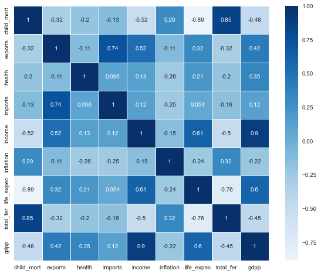

```python
# Exibe a correlação de colunas do dataframe
plot_columns_correlation(original_df)
```

> Como pode ser visto no gráfico acima, existem colunas com correlações fortes que poderiam ser analisadas de forma destacada do dataset completo, permitindo análises mais específicas.

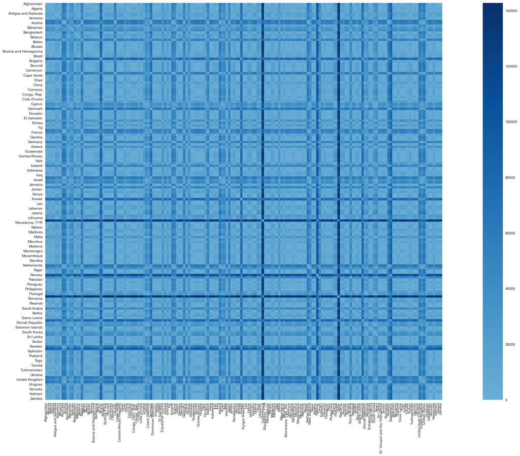

```python
# Exibe o gráfico de distância (euclidiana) entre as colunas do dataframe
plot_distance_matrix_chart(original_df, False)
```

> No gráfico acima, o volume de dados não nos permite ter uma visão precisa da relação dos das colunas.

```python
# Exibe a estrutura dos dados
# original_df.info()

# Verifica se existem colunas com dados ausentes
# original_df.isnull().sum()

# Verifica a presença de países duplicados
duplicated_analysis_series = original_df.duplicated()
duplicate_countries = len(duplicated_analysis_series[duplicated_analysis_series == True])

# Resumo do dataframe original.
print(
    '- {} países distintos (linhas) e {} colunas no dataframe. \n      A coluna "country" foi transformada em index. \n- {} colunas contém "missing values". \n- {} países estão duplicados.'.format(
        len(original_df), original_df.shape[1], original_df.isnull().sum().sum(), duplicate_countries
    )
)
```

```
- 167 países distintos (linhas) e 9 colunas no dataframe.
      A coluna "country" foi transformada em index.
- 0 colunas contém "missing values".
- 0 países estão duplicados.
```

> Olhando para um cenário global, países como México, Cuba, Porto Rico, Groelândia, Etiópia, entre outros, estão ausentes do dataset.

```python
# Exibe descrição estatística
original_df.describe().T
```

|  | count | mean | std | min | 25% | 50% | 75% | max |
| --- | --- | --- | --- | --- | --- | --- | --- | --- |
| child_mort | 167.0 | 38.270060 | 40.328931 | 2.6000 | 8.250 | 19.30 | 62.10 | 208.00 |
| exports | 167.0 | 41.108976 | 27.412010 | 0.1090 | 23.800 | 35.00 | 51.35 | 200.00 |
| health | 167.0 | 6.815689 | 2.746837 | 1.8100 | 4.920 | 6.32 | 8.60 | 17.90 |
| imports | 167.0 | 46.890215 | 24.209589 | 0.0659 | 30.200 | 43.30 | 58.75 | 174.00 |
| income | 167.0 | 17144.688623 | 19278.067698 | 609.0000 | 3355.000 | 9960.00 | 22800.00 | 125000.00 |
| inflation | 167.0 | 7.781832 | 10.570704 | -4.2100 | 1.810 | 5.39 | 10.75 | 104.00 |
| life_expec | 167.0 | 70.555689 | 8.893172 | 32.1000 | 65.300 | 73.10 | 76.80 | 82.80 |
| total_fer | 167.0 | 2.947964 | 1.513848 | 1.1500 | 1.795 | 2.41 | 3.88 | 7.49 |
| gdpp | 167.0 | 12964.155689 | 18328.704809 | 231.0000 | 1330.000 | 4660.00 | 14050.00 | 105000.00 |

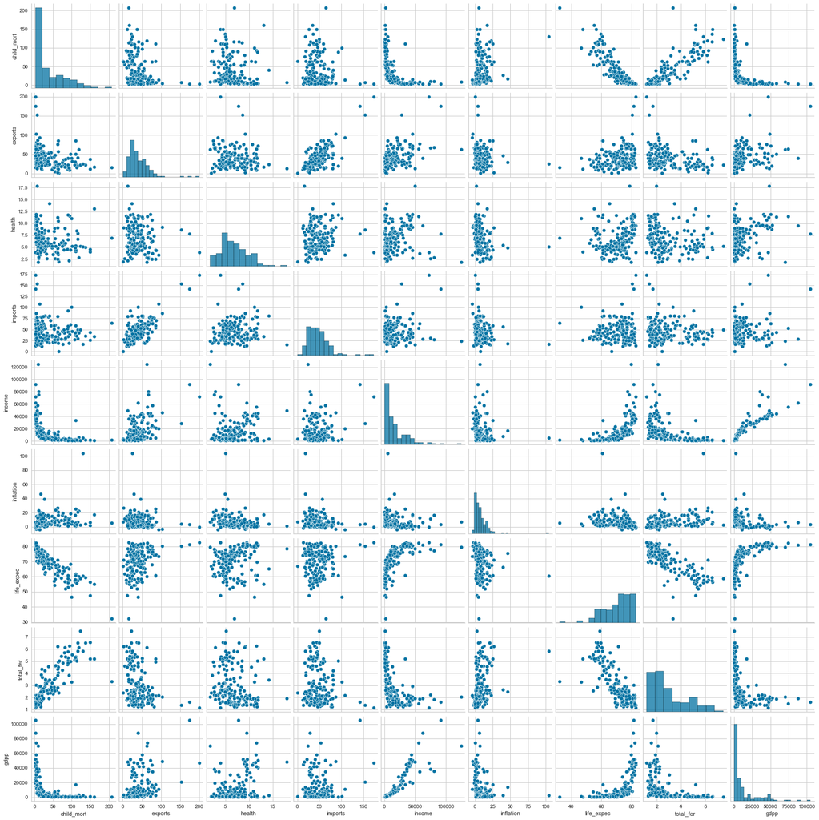

```python
# Exibe o gráfico de relação dos dados do dataframe por pares de colunas.
sb.pairplot(data=original_df);

# g = sb.PairGrid(original_df, vars=original_df.columns);
# g.map_diag(sb.kdeplot, lw=2);
# g.map_offdiag(plt.scatter);
```

> O que deve ser feito com os dados antes da etapa de clusterização?

Os dados devem ser normalizados e os outliers, caso existam, devem ser removidos.

### Pré-processamento dos Dados

> A coluna de nome dos países foi removida e transformada em index na leitura dos dados do arquivo csv

```python
# Normaliza os dados gerando um novo dataframe
normalized_mean_std_df = (original_df - original_df.mean(axis=0))/ original_df.std(axis=0)
normalized_min_max_df = (original_df-original_df.min())/(original_df.max()-original_df.min())
standard_scaler_normalized = StandardScaler().fit_transform(original_df)
min_max_normalized = MinMaxScaler().fit_transform(original_df)
```

```python
# Define o dataframe de trabalho segundo a normalização escolhida
normalized_df = normalized_mean_std_df
# normalized_df = normalized_min_max_df
```

## Clusterização

#### KMeans

```python
# Como o enunciado já determina o número de clusters, este se torna irrelevante.

# Gera o gráfico de cotovelo para análise de número de clusters.
# plot_elbow_analysis(original_df)
```

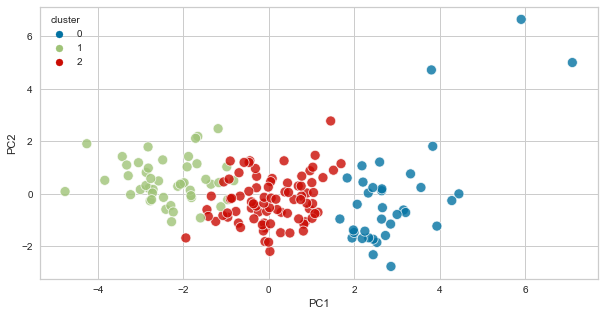

```python
# Clusteriza os dados por kmeans e exibe o gráfico de clusters
df, cluster_labels, centroids = get_kmeans_cluster(normalized_df)
clustered_df = cluster(cluster_labels, normalized_df)
plot_cluster(clustered_df, cluster_labels, centroids)
```

```python
# Separa os dados em dataframes por cluster
kmeans_cluster_0_df =  clustered_df[(clustered_df['kmeans_cluster'] == 0)]
kmeans_cluster_1_df =  clustered_df[(clustered_df['kmeans_cluster'] == 1)]
kmeans_cluster_2_df =  clustered_df[(clustered_df['kmeans_cluster'] == 2)]
```

> Para os resultados do K-Médias, interprete cada um dos clusters obtidos citando a distribuição das dimensões em cada grupo.

```python
print('Distribuição de elementos por clusters KMeans: \n- Cluster 0: {} itens \n- Cluster 1: {} itens \n- Cluster 2: {} itens'.format(
    len(kmeans_cluster_0_df), len(kmeans_cluster_1_df), len(kmeans_cluster_2_df)))
```

```
Distribuição de elementos por clusters KMeans:
- Cluster 0: 36 itens
- Cluster 1: 47 itens
- Cluster 2: 84 itens
```

```python
(kmeans_cluster_0_df.describe().T)
```

|  | count | mean | std | min | 25% | 50% | 75% | max |
| --- | --- | --- | --- | --- | --- | --- | --- | --- |
| child_mort | 36.0 | -0.824968 | 0.054277 | -0.884478 | -0.860922 | -0.844804 | -0.806370 | -0.681150 |
| exports | 36.0 | 0.643146 | 1.529650 | -1.047314 | -0.416204 | 0.337116 | 0.978258 | 5.796402 |
| health | 36.0 | 0.725230 | 1.156972 | -1.822346 | 0.334680 | 0.957214 | 1.441407 | 4.035299 |
| imports | 36.0 | 0.190067 | 1.521876 | -1.375084 | -0.763756 | -0.323848 | 0.661299 | 5.250390 |
| income | 36.0 | 1.479792 | 1.081645 | 0.417848 | 0.793924 | 1.214090 | 1.529215 | 5.594716 |
| inflation | 36.0 | -0.483467 | 0.385757 | -1.040785 | -0.693457 | -0.623594 | -0.391112 | 0.843668 |
| life_expec | 36.0 | 1.076341 | 0.204173 | 0.555967 | 1.005750 | 1.101329 | 1.219397 | 1.376822 |
| total_fer | 36.0 | -0.789502 | 0.246428 | -1.187678 | -0.997765 | -0.748400 | -0.654269 | 0.054190 |
| gdpp | 36.0 | 1.611150 | 1.036139 | 0.198369 | 0.966290 | 1.540526 | 1.937444 | 5.021405 |
| kmeans_cluster | 36.0 | 0.000000 | 0.000000 | 0.000000 | 0.000000 | 0.000000 | 0.000000 | 0.000000 |

```python
(kmeans_cluster_1_df.describe().T)
```

|  | count | mean | std | min | 25% | 50% | 75% | max |
| --- | --- | --- | --- | --- | --- | --- | --- | --- |
| child_mort | 47.0 | 1.356139 | 0.827575 | -0.033972 | 0.633043 | 1.287660 | 1.803418 | 4.208640 |
| exports | 47.0 | -0.436221 | 0.662505 | -1.419413 | -0.881328 | -0.631438 | -0.106120 | 1.630345 |
| health | 47.0 | -0.155516 | 0.969120 | -1.680365 | -0.835757 | -0.420734 | 0.469380 | 2.287835 |
| imports | 47.0 | -0.188636 | 0.732468 | -1.226382 | -0.705928 | -0.272215 | 0.105734 | 2.235056 |
| income | 47.0 | -0.684834 | 0.292653 | -0.857746 | -0.817234 | -0.792335 | -0.698705 | 0.858764 |
| inflation | 47.0 | 0.400905 | 1.467259 | -0.652448 | -0.356819 | 0.107672 | 0.834208 | 9.102343 |
| life_expec | 47.0 | -1.278335 | 0.724547 | -4.324181 | -1.563637 | -1.243166 | -0.866472 | 0.061206 |
| total_fer | 47.0 | 1.360851 | 0.687904 | -0.236460 | 1.048346 | 1.395144 | 1.774971 | 3.000326 |
| gdpp | 47.0 | -0.602431 | 0.161283 | -0.694711 | -0.677307 | -0.658375 | -0.627112 | 0.225648 |
| kmeans_cluster | 47.0 | 1.000000 | 0.000000 | 1.000000 | 1.000000 | 1.000000 | 1.000000 | 1.000000 |

```python
(kmeans_cluster_2_df.describe().T)
```

|  | count | mean | std | min | 25% | 50% | 75% | max |
| --- | --- | --- | --- | --- | --- | --- | --- | --- |
| child_mort | 84.0 | -0.405235 | 0.341143 | -0.837366 | -0.660074 | -0.493940 | -0.245979 | 0.647920 |
| exports | 84.0 | -0.031558 | 0.694191 | -1.495694 | -0.523821 | -0.138953 | 0.375420 | 1.922188 |
| health | 84.0 | -0.223798 | 0.788992 | -1.764097 | -0.713799 | -0.322439 | 0.199069 | 2.688296 |
| imports | 84.0 | 0.024089 | 0.830410 | -1.934123 | -0.608859 | 0.072690 | 0.559067 | 2.524198 |
| income | 84.0 | -0.251015 | 0.424320 | -0.797004 | -0.545163 | -0.361275 | -0.025661 | 1.465671 |
| inflation | 84.0 | -0.017116 | 0.742573 | -1.134440 | -0.512202 | -0.187010 | 0.212206 | 3.606020 |
| life_expec | 84.0 | 0.253970 | 0.445369 | -0.995785 | -0.039996 | 0.342320 | 0.623435 | 1.106952 |
| total_fer | 84.0 | -0.423070 | 0.460388 | -1.121622 | -0.791337 | -0.470962 | -0.188569 | 0.919535 |
| gdpp | 84.0 | -0.353418 | 0.273966 | -0.675015 | -0.545410 | -0.452523 | -0.212462 | 0.820344 |
| kmeans_cluster | 84.0 | 2.000000 | 0.000000 | 2.000000 | 2.000000 | 2.000000 | 2.000000 | 2.000000 |

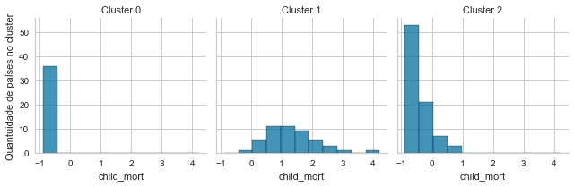

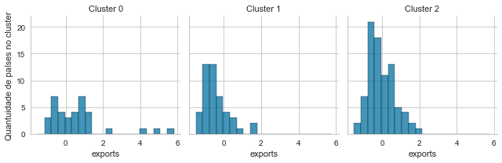

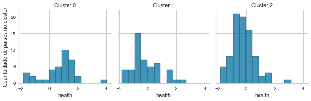

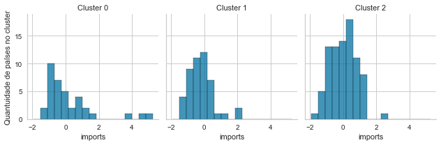

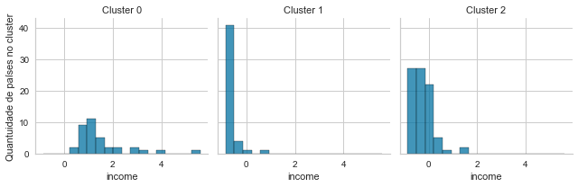

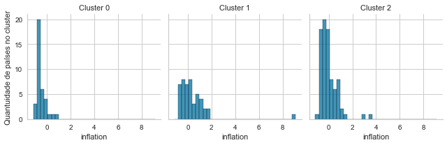

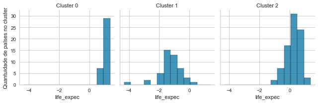

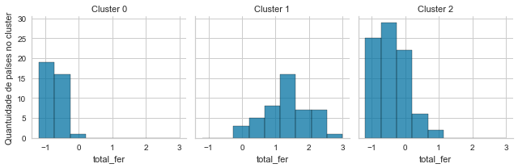

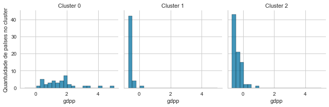

```python
columns = ['child_mort', 'exports', 'health', 'imports', 'income', 'inflation', 'life_expec', 'total_fer', 'gdpp']

for i in range(len(columns)):
    g = sb.displot(data=clustered_df, x=columns[i], col='kmeans_cluster', height=3, aspect=1)
    g.set_axis_labels(columns[i], 'Quantuidade de países no cluster')
    g.set_titles('Cluster {col_name}')
```

> Para os resultados do K-Médias, o país, de acordo com o algoritmo, melhor representa o seu agrupamento.

```python
# Identifica o país, de acordo com o algoritmo, melhor representa o seu cluster
print('- Cluster 0: {} \n- Cluster 1: {} \n- Cluster 2: {}'.format(
    ''.join(get_cluster_nearest_centroid_point(kmeans_cluster_0_df, 0).index),
    ''.join(get_cluster_nearest_centroid_point(kmeans_cluster_1_df, 1).index),
    ''.join(get_cluster_nearest_centroid_point(kmeans_cluster_2_df, 2).index))
)
```

```
- Cluster 0: Austria
- Cluster 1: Afghanistan
- Cluster 2: Argentina
```

#### Clusterização Hierárquica

```python
# clustered_df['hierarchical_cluster'] = (get_agglomerative_pca_clustering(normalized_df, clusters_number)).labels_
clustered_df['hierarchical_cluster'] = (get_agglomerative_clustering(normalized_df, clusters_number)).labels_
clustered_df.head()
```

| country | child_mort | exports | health | imports | income | inflation | life_expec | total_fer | gdpp | kmeans_cluster | hierarchical_cluster |
| --- | --- | --- | --- | --- | --- | --- | --- | --- | --- | --- | --- |
| Afghanistan | 1.287660 | -1.134867 | 0.278251 | -0.082208 | -0.805822 | 0.156864 | -1.614237 | 1.897176 | -0.677143 | 1 | 2 |
| Albania | -0.537333 | -0.478220 | -0.096725 | 0.070624 | -0.374243 | -0.311411 | 0.645924 | -0.857394 | -0.484167 | 2 | 1 |
| Algeria | -0.272015 | -0.098824 | -0.963176 | -0.639838 | -0.220182 | 0.786908 | 0.668413 | -0.038289 | -0.463980 | 2 | 1 |
| Angola | 2.001787 | 0.773056 | -1.443729 | -0.164820 | -0.583289 | 1.382894 | -1.175698 | 2.121770 | -0.514720 | 1 | 1 |
| Antigua and Barbuda | -0.693548 | 0.160186 | -0.286034 | 0.496076 | 0.101427 | -0.599944 | 0.702147 | -0.540321 | -0.041692 | 2 | 1 |

> Para os resultados da Clusterização Hierárquica, apresente o dendograma e interprete os resultados

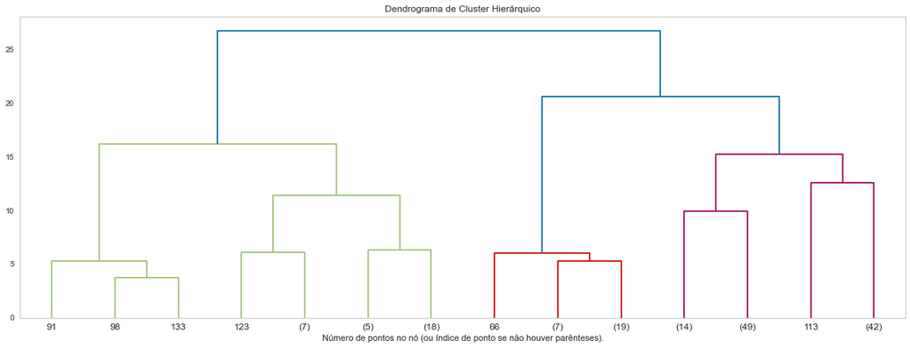

```python
# # Exibe o dendrograma "aberto", exibindo todos os países
# # plot_open_dendrogram(normalized_df)

# # Exibe o dendrograma hierárquico
# plot_hierarchical_dendrogram(normalized_df, get_agglomerative_pca_clustering(normalized_df), truncate_mode="level", p=3)
plot_hierarchical_dendrogram(normalized_df, get_agglomerative_clustering(normalized_df), truncate_mode="level", p=3)
```

> Se a linha de corte for mais alta, haveria menos agrupamentos finais, mas o nível de similaridade seria menor.

> Se a linha de corte for mais baixa, o nível de similaridade seria maior, mas haveria mais agrupamentos finais.

#### Clusterização Hierárquica X KMeans

> Compare os dois resultados, aponte as semelhanças e diferenças e interprete.

```python
clustered_df[['kmeans_cluster', 'hierarchical_cluster']].head()
```

| country | kmeans_cluster | hierarchical_cluster |
| --- | --- | --- |
| Afghanistan | 1 | 2 |
| Albania | 2 | 1 |
| Algeria | 2 | 1 |
| Angola | 1 | 1 |
| Antigua and Barbuda | 2 | 1 |

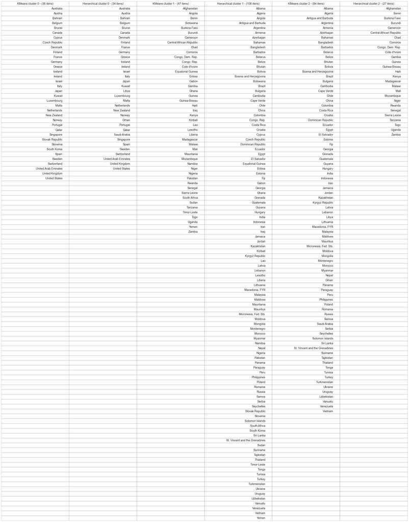

```python
# Tipos
# 1- KMeans
# 2- Hierarchical
# 3- Both

# Exibe a tabela de clusters por KMeans
#plot_table(clustered_df, clusters_number, 1);

# Exibe a tabela de clusters hierárquicos
#plot_table(clustered_df, clusters_number, 2);

# Exibe tabela comparando os resultados da clusterização hierarquica x KMeans
plot_table(clustered_df, clusters_number, 3);
```

```python
# Separa os dados em dataframes por cluster
hierarchical_cluster_0_df =  clustered_df[(clustered_df['hierarchical_cluster'] == 0)]
hierarchical_cluster_1_df =  clustered_df[(clustered_df['hierarchical_cluster'] == 1)]
hierarchical_cluster_2_df =  clustered_df[(clustered_df['hierarchical_cluster'] == 2)]
```

```python
print('Distribuição de elementos por clusters \n\n A distribuição por KMeans está mais balanceada do que a distribuição hierárquica.\n- Cluster 0: \n  - KMeans: {} itens \n  - Hierárquica: {} items \n- Cluster 1: \n  - KMeans: {} itens \n  - Hierárquica: {} items \n- Cluster 2: \n  - KMeans: {} itens \n  - Hierárquica: {} items'.format(
    len(kmeans_cluster_0_df), len(hierarchical_cluster_0_df), len(kmeans_cluster_1_df),  len(hierarchical_cluster_1_df), len(kmeans_cluster_2_df), len(hierarchical_cluster_2_df)))
```

```
Distribuição de elementos por clusters

 A distribuição por KMeans está mais balanceada do que a distribuição hierárquica.
- Cluster 0:
  - KMeans: 36 itens
  - Hierárquica: 34 items
- Cluster 1:
  - KMeans: 47 itens
  - Hierárquica: 106 items
- Cluster 2:
  - KMeans: 84 itens
  - Hierárquica: 27 items
```

```python
# Gera um dataframe final com os dados originais rotulados.
clusterized_original_df = original_df.copy()
clusterized_original_df['kmeans_cluster'] = clustered_df['kmeans_cluster']
clusterized_original_df['hierarchical_cluster'] = clustered_df['hierarchical_cluster']

# Agrupa os dados para análise
kmeans_cluster_description = clusterized_original_df.groupby("kmeans_cluster")[clusterized_original_df.columns.tolist()]
# kmeans_cluster_description = clusterized_original_df.groupby("kmeans_cluster")['child_mort', 'exports', 'health', 'imports', 'income', 'inflation', 'life_expec', 'total_fer', 'gdpp', 'kmeans_cluster']
kmeans_n_clients = kmeans_cluster_description.size()
kmeans_cluster_description = kmeans_cluster_description.mean()
kmeans_cluster_description['n_clients'] = kmeans_n_clients

hierarchical_cluster_description = clusterized_original_df.groupby("hierarchical_cluster")[clusterized_original_df.columns.tolist()]
# hierarchical_cluster_description = clusterized_original_df.groupby("hierarchical_cluster")['child_mort', 'exports', 'health', 'imports', 'income', 'inflation', 'life_expec', 'total_fer', 'gdpp', 'hierarchical_cluster']
hierarchical_n_clients = hierarchical_cluster_description.size()
hierarchical_cluster_description = hierarchical_cluster_description.mean()
hierarchical_cluster_description['n_clients'] = hierarchical_n_clients
```

```python
kmeans_cluster_description[['child_mort', 'exports', 'health', 'imports', 'income', 'inflation', 'life_expec', 'total_fer', 'gdpp']]
```

| kmeans_cluster | child_mort | exports | health | imports | income | inflation | life_expec | total_fer | gdpp |
| --- | --- | --- | --- | --- | --- | --- | --- | --- | --- |
| 0 | 5.000000 | 58.738889 | 8.807778 | 51.491667 | 45672.222222 | 2.671250 | 80.127778 | 1.752778 | 42494.444444 |
| 1 | 92.961702 | 29.151277 | 6.388511 | 42.323404 | 3942.404255 | 12.019681 | 59.187234 | 5.008085 | 1922.382979 |
| 2 | 21.927381 | 40.243917 | 6.200952 | 47.473404 | 12305.595238 | 7.600905 | 72.814286 | 2.307500 | 6486.452381 |

##### Interpretação dos Clusters KMeans

- Cluster 0:
  - Menor mortalidade de crianças menores de 5 anos por 1.000 nascidos vivos
  - Maiores exportações de bens e serviços per capita.
  - Maior gasto total em saúde per capita.
  - Maiores importações de bens e serviços per capita.
  - Maior renda líquida por pessoa
  - Menor taxa de inflação
  - Maior expectativa de vida
  - Maior O PIB per capita
- Cluster 1:
  - Maior mortalidade de crianças menores de 5 anos por 1.000 nascidos vivos
  - Menores exportações de bens e serviços per capita.
  - Menores importações de bens e serviços per capita.
  - Menor renda líquida por pessoa
  - Maior taxa inflação
  - Menor expectativa de vida
  - Menor O PIB per capita.
- Cluster 2:
  - Menor gasto total com saúde per capita.

```python
hierarchical_cluster_description[['child_mort', 'exports', 'health', 'imports', 'income', 'inflation', 'life_expec', 'total_fer', 'gdpp']]
```

| hierarchical_cluster | child_mort | exports | health | imports | income | inflation | life_expec | total_fer | gdpp |
| --- | --- | --- | --- | --- | --- | --- | --- | --- | --- |
| 0 | 5.961765 | 58.508824 | 8.501176 | 48.902941 | 47588.235294 | 4.115500 | 79.982353 | 1.888529 | 43170.588235 |
| 1 | 31.617925 | 39.990368 | 6.353679 | 48.085527 | 11341.886792 | 9.120604 | 70.921698 | 2.654623 | 6407.367925 |
| 2 | 105.070370 | 23.589630 | 6.507037 | 39.662963 | 1589.740741 | 7.142778 | 57.248148 | 5.433704 | 667.888889 |

##### Interpretação dos Clusters Hierárquicos

- Cluster 0:
  - Menor mortalidade de crianças menores de 5 anos por 1.000 nascidos vivos
  - Maiores exportações de bens e serviços per capita
  - Maior gasto total em saúde per capita
  - Maiores importações de bens e serviços per capita
  - Maior renda líquida por pessoa
  - Menor taxa de inflação
  - Maior expectativa de vida
  - Maior O PIB per capita
- Cluster 1:
  - Menor Gasto total com saúde per capita
  - Maior taxa de inflação
- Cluster 2:
  - Maior mortalidade de crianças menores de 5 anos por 1.000 nascidos vivos
  - Menores exportações de bens e serviços per capita
  - Menores importações de bens e serviços per capita
  - Menor renda líquida por pessoa
  - Menor expectativa de vida
  - Menor O PIB per capita

> Comparando as duas interpretações, pode-se dizer que. Apesar dos rótulos dos clustes 1 e 2 parecerem invertidos, a distribuição dos pontos me parece coerente.

### Escolha de algoritmos

##### 1. Escreva em tópicos as etapas do algoritmo de K-médias até sua convergência.

> Resposta
1. Inicializar k centróides em pontos aleatórios
2. Para cada ponto, encontrar o centróide mais próximo
3. Calcular o baricentro dos pontos de cada centróide
4. Mover o centróide na direção do seu baricentro
5. Repetir, a partir do passo 2, até a convergência do algorítimo

*O algoritmo converge quando o movimento for menor que um valor pré-definido, quando os elementos de cada cluster não mudam ou quando o número de iterações pré-especificado for atingido.*

##### 2. O algoritmo de K-médias converge até encontrar os centróides que melhor descrevem os clusters encontrados (até o deslocamento entre as interações dos centróides ser mínimo).

##### Lembrando que o centróide é o baricentro do cluster em questão e não representa, em via de regra, um dado existente na base.

##### Refaça o algoritmo apresentado na questão 1 a fim de garantir que o cluster seja representado pelo dado mais próximo ao seu baricentro em todas as iterações do algoritmo.

*Obs: nesse novo algoritmo, o dado escolhido será chamado medóide. (rever a aula do kmedoids)*

> Resposta

Medoid é definido como o objeto no cluster cuja dissimilaridade média para todos os objetos no cluster é mínima, ou seja, é um ponto central do cluster.

1. Selecionar k **objetos** aleatóreos no conjunto de dados e definir como medóids. *Em comparação com KMeans, ao invés de sortear k pontos aleatóreos, k objetos serão selecionados do dataset.*
2. Calcular a matriz de dissimilaridade.
3. Atribuir cada ponto ao seu medóide mais próximo.
4. Para cada cluster, verificar se existe algum ponto mais central do que o medóide inicialmente escolhido. (Dissimilaridade dele para todos os outros pontos do cluster é menor).
5. Repetir a partir do passo 3 até a convergência do algorítimo.

##### 3. O algoritmo de K-médias é sensível a outliers nos dados. Explique.

> Resposta

Sim. Porque outliers são pontos isolados que se diferenciam drasticamente de todos os outros. Como KMeans é baseado em médias, os outliers afetam o cálculo exercendo peso e fazendo com que o centroid seja deslocado de um ponto razoável, ficando longe dos pontos na qual ele deveria estar ligado.

##### 4. Por que o algoritmo de DBScan é mais robusto à presença de outliers?

> Resposta

Porque é um algorítimo baseado em densidade. Onde, dado o conjunto de pontos no espaço, agrupa os pontos próximos marcando como ruído os pontos isolados em região de baixa densidade. Os ruídos recebem o rótulo -1.